# Premature Calibration

Ernesto

March 31, 2017

## Calibrating California

We have a semi-working model of California. Most of its parameters are fixed by data (say, gas price, fish abundance, selectivity functions, and so on). We need access to logbook data to fit behavioural parameters. However we still have two “free” parameters we need to set. We have `catchability` (proportion of fish in cell that is met by the gear) and `hold size` (maximum fish a boat can haul back). We want to calibrate them, that is set them such that the model output resembles the most the data we have.

Strictly speaking `hold size` could be fixed from data as well, but that requires us both making boats heterogeneous in size (which is easy because we have data on this) and distribute these boats correctly amongst ports (and we don’t really have this joint distribution). So finding `hold size` is really trying to find the correct size of the hypothetical “average” ship (at least for a first pass approximation).  
Stock assessments provide a `catchability` estimate, but that refers to ocean-wide probability of meeting fish per hour of effort while we need it cell-wise. We could divide it by # of cells but in reality fishers put effort where most fish is, not equally, so that in practice we need to back out `catchability` separately.

Imagine we initialize the model with 2010 values (pre-ITQ). We know how many boats there are, we know how many hours they were out, we know how much fish there was in the sea. If we force agents to only go out that many hours, using explore-exploit-imitate because logbook data is still not here, can we figure out what `hold size` and `catchability` ought to be such that the agents produce the right amount of **landings** and **profits** (which we know from catcher-vessel report)?

## Calibrate on Profits

In 2010, the average profit $\pi$ (ignoring fixed costs) made by boats in the DTS was: 99,200$. Can we change `hold size` $Z$ and `catchability` $q$ so that agents in our model also make on average that much money?
This is just another optimization where we minimize:
$$\text{error}_{\pi} = \left[ \pi(Z,q) - 99200 \right]^2$$

We can deploy our usual Bayesian Optimizer and get the error posterior:

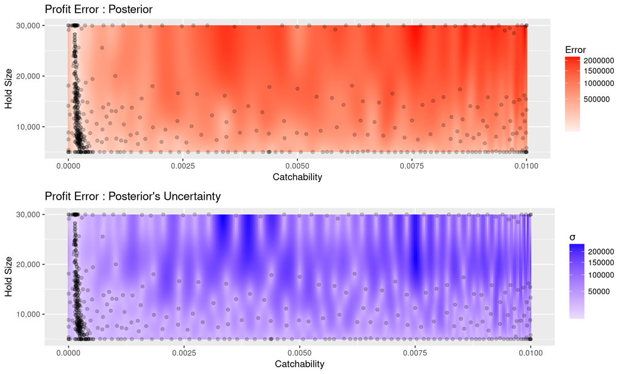

We are looking for the minimum, so the white area. The minimum is at `catchability` of 0.000239, and `hold size` of 7498kg.

## Calibrate on Landings

We also have data on landings $\bar L$ in the 2010 DTS fishery for each species. We can ask ourselves for what values of `catchability` and `hold size` we would get the same amount of landings $L$ for each species $i$. The error now is:
$$\text{error}_{L} = \sum_{i}\left[ L_i(Z,q) - \bar L \right]^2$$

Same optimization problem, just different score and we get the following posterior:

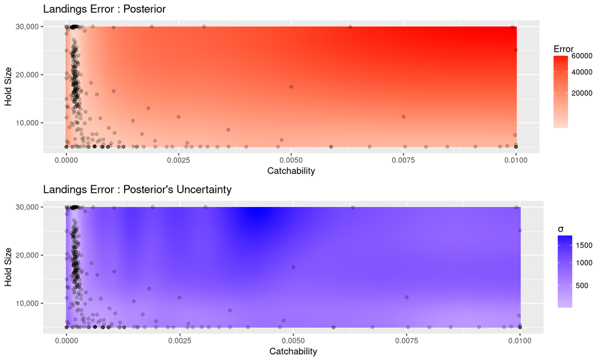

The white area has similar catchability but higher hold size. The minimum is at `catchability` of 0.000196, and `hold size` of 19875kg.

## Calibrate on Both

Now, the real problem is that we have two targets we want to hit in the same optimization. We have seen this kind of problems before: we are really looking for a Pareto Front where we look for the parameter sets that tradeoff profit error with landings error.

We can use the same tools as usual (NSGA-II optimization) and we get the following front:

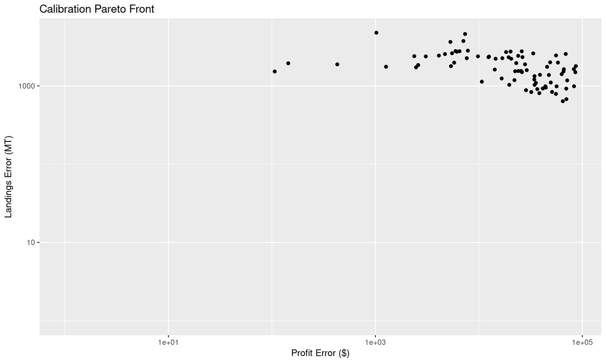

It reads like any Pareto front except that now dots that are low and to the left are “better” (lower error). As you can see, you really gain very little in terms of landings errors by increasing profit errors. This is a good result because it means that the two errors tend to increase/decrease together. This was somewhat visible by the fact that the “white areas” in the Bayesian calibrations were close to each other.

We can super-inpose these pareto points on the original Bayesian posterior to see where they are in the parameter-space (rather than the objective-space as shown in the Pareto front). I do so in the next figure (the blue dots are the Pareto candidates).

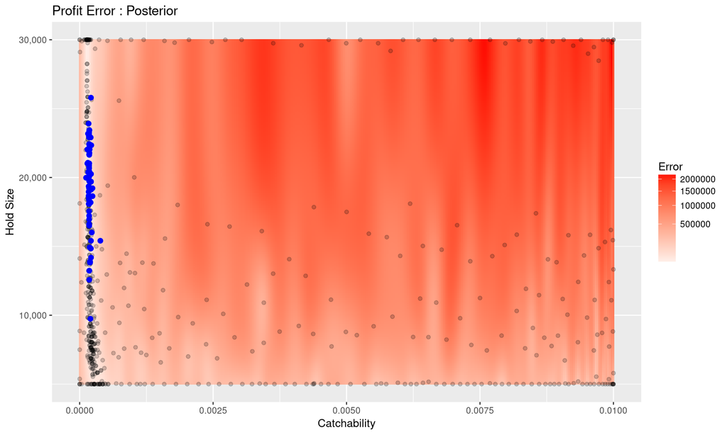

They are in the white area, as predicted, and usually with hold-size above 10,000 (which is where the white area of the landings error was located).

## How it looks like

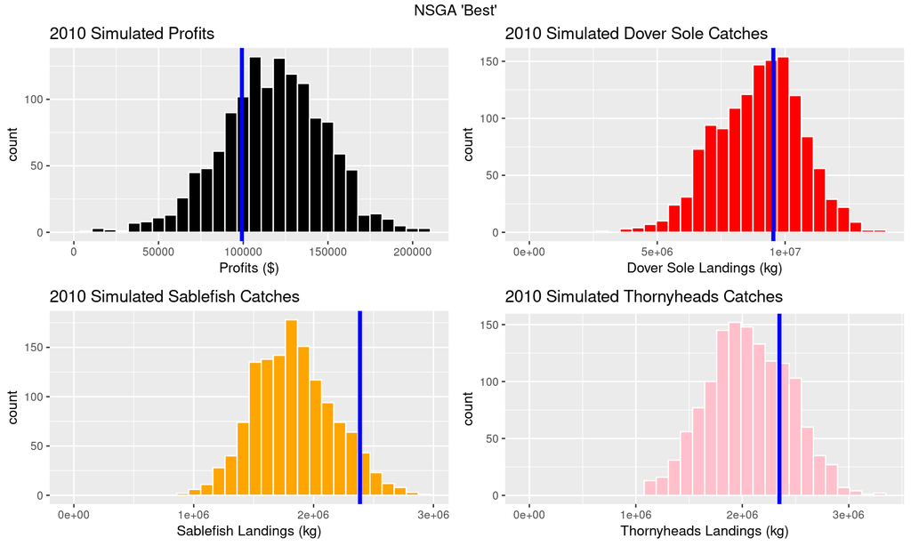

The calibration results are pretty good! There is a bit of under-landings of sablefish but I think the problem is that sablefish is so expensive that I am uncovering a tradeoff between catching more sablefish and balooning profits.

This will have to be redone when logbook data arrives, but until then we are in a pretty good space.